# Slide styles for the Utrecht talk, second round

The first round had several of the habits that current design critics list as signs of AI-generated work. This round has three new styles, each built from something already in the book or the talk: the figures and their annotations, Michael’s corrgram, and the penguins themselves. A fourth, Contour v2, reworks the first-round Contour style without its tells. The first-round styles are kept at the bottom of the page, each with a list of the tells it shows.

Things this round avoids, from those lists:

- small all-caps or letter-spaced labels above titles (“eyebrows”), and monospace labels used as decoration
- strings of facts joined by dots, such as “Utrecht · 5 Nov · 2026”
- cream paper with a serif and a rust accent, and near-black slides with one bright accent
- italic or colored words in headlines, big stand-alone numbers, and boxes with a colored stripe down one side
- centered layouts, hairline-rule “newspaper” styling, pill-shaped tags, gradient fades, and shapes that are only decoration
- the same layout on every slide

## Annotated figure

The figure is the slide. Titles are plain sentences that state what the figure shows, and notes sit next to the data they describe, linked by leader lines and colored like the species they name. The only other element is the slide number. The section divider is the talk outline with the current section in black, as a Beamer outline would show it.

Atkinson Hyperlegible Next, chosen for legibility at a distance; it was designed for low-vision readers.

white

ink

Adelie

Chinstrap

Gentoo

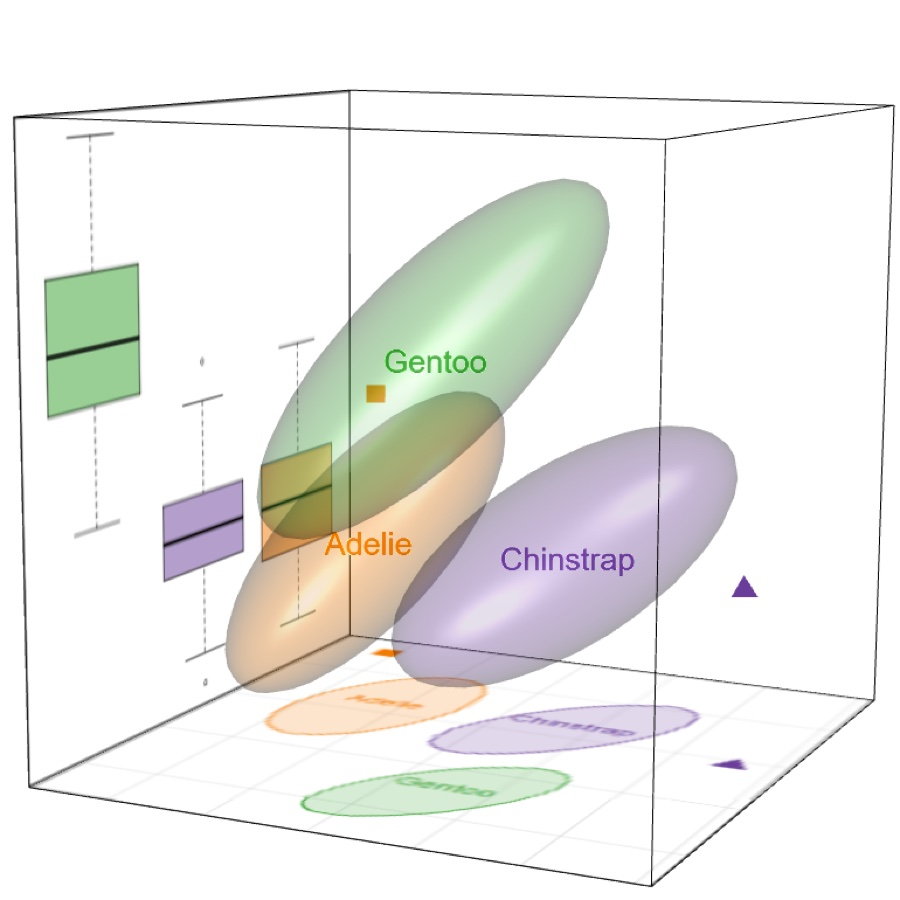

### Visualizing Multivariate Data and Models in R

A romance in many dimensions

**Michael Friendly**  
York University  
Utrecht, 5 November 2026

Title slide. The 3D ellipsoids from the cover run off the edge of the slide.

1. 1Ellipses everywhere: seeing multivariate dataGalton’s ellipse, the data ellipse, non-normal data, Simpson’s paradox, scatterplot matrices and tours
2. 2Multivariate juicers and Waldo space
3. 3Elliptical insights
4. 4The HE plot framework
5. 5Checking multivariate models

10

Section divider: the outline, with the current section in black and an ellipse marking it.

### Each species has its own region of bill space

**Adelie**short, deep bills

**Chinstrap**long, deep bills

**Gentoo**long, shallow bills

12

Figure slide: a sentence title and three notes that point into the plot.

### Ignore species, and bill length and depth look negatively related

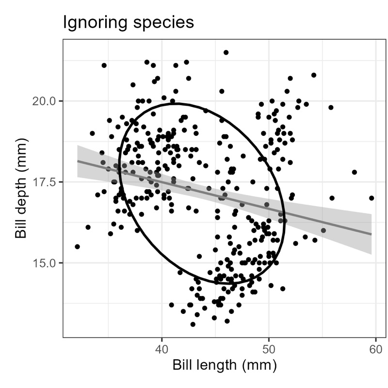

All 333 penguins: r = −0.23

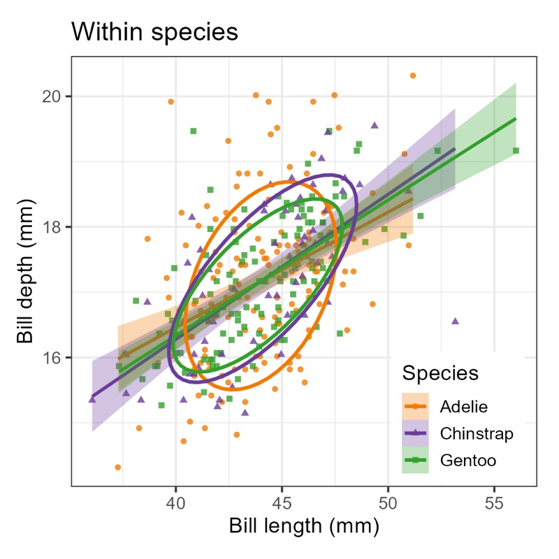

Within species: r = +0.53

18

Comparison slide: the before and after of Simpson’s paradox, with the correlations computed from `heplots::peng`.

**Why it suits the talk.** This is how people who work with data tend to present it: the plot carries the argument and the text answers “what am I looking at?” It also matches Michael’s own habit of annotating plots directly instead of using legends.

**What to watch.** Each callout has to be placed by hand on each figure, so it takes the most work per slide. Use callouts only where they help, perhaps 10 to 15 slides, and let the other figures stand alone with a sentence title.

**In PowerPoint.** Callouts are text boxes with straight connector lines. The outline divider is one layout, copied five times with a different line in bold. Atkinson Hyperlegible Next is a free Google font.

## Corrgram

Built on the corrgram, which Michael introduced in 2002. Blue means positive correlation and red negative, as in his original. Ellipses are drawn above the diagonal and shaded cells below. Slides are laid out in square cells like the panels of a scatterplot matrix, and every corrgram on these slides is computed from the penguin data.

Libre Franklin, a revival of Franklin Gothic, with tabular figures so numbers line up

positive

negative

cell

ink

white

### Visualizing Multivariate Data and Models in R

A romance in many dimensions

**Michael Friendly**  
York University  
Utrecht, 5 November 2026

[figure not shown]

Correlations among the four penguin measurements

Title slide: a corrgram of the penguin data.

3

### Elliptical insights

Outliers, measurement error, collinearity and ridge regression.

[figure not shown]

Threads shared between sections; row and column 3 are this section.

31

Section divider: a matrix of the talk’s five sections, with the ideas that link them.

### Within species, every correlation is positive

All penguins

[figure not shown]

Within species

[figure not shown]

18

Simpson’s paradox in corrgram form: the bill length–bill depth cell turns from red to blue.

### Every pair of measures separates the species

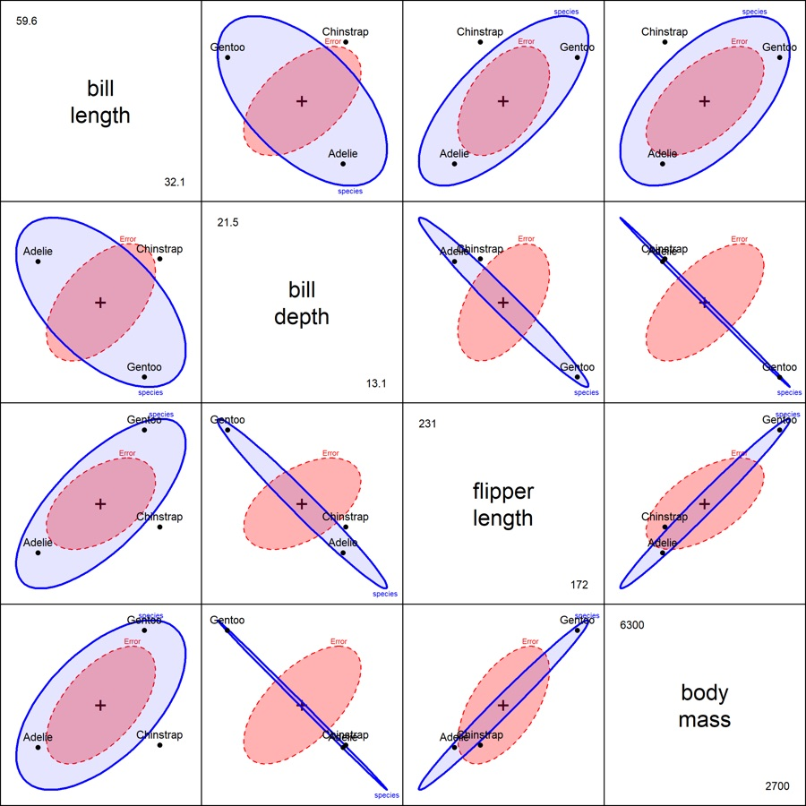

Each panel is an HE plot for one pair of variables, set out like a scatterplot matrix.

In every panel the H ellipse for species reaches well beyond the E ellipse for error.

52

Figure slide: the HE pairs plot, with the text colored to match its two kinds of ellipse.

**Why it suits the talk.** The corrgram is Michael’s own idea and sits halfway between the data and the ellipse, so it connects the opening sections to the multivariate ones. The square-cell layout borrows its structure from the scatterplot matrices and HE pairs plots that appear in the talk.

**What to watch.** The blue and red now carry meaning, so they should not be used for anything else; links and emphasis stay black. The threads matrix on the divider needs care to stay readable from the back of the room. If it is too small, keep only row and column 3.

**In PowerPoint.** Draw the corrgrams in R with `corrgram::corrgram()` or `corrplot` and paste them in as images. The threads matrix is a PowerPoint table with one cell shaded.

## Field guide

The penguins are the talk’s recurring characters, so this style borrows from bird guides. Species have their Latin names and their plotting symbols (□ ● ▲). Section dividers are identification keys that lead to the right plot, and comparisons use a species table with real means. Italic is used only where a field guide would use it, for Latin names.

Alegreya Sans, a humanist sans with true italics for the Latin names

white

ink

Adelie

Chinstrap

Gentoo

### Visualizing Multivariate Data and Models in R

A romance in many dimensions

Michael Friendly, York University. Utrecht, 5 November 2026.

Title slide: the three species shown as specimens, each as its bill-shape ellipse.

### Ellipses everywhere

A key to the plots in this section

| 1a | One group, two variables | go to 2 |
| --- | --- | --- |
| 1b | Several groups | go to 3 |
| 2a | The cloud looks roughly normal | data ellipse *(12)* |
| 2b | The cloud is skewed or clumped | bagplot or HDR *(17)* |
| 3a | Groups share a common slope | one ellipse per group *(14)* |
| 3b | The overall trend disagrees with the groups | Simpson’s paradox *(18)* |

10

Section divider as an identification key, with slide numbers in brackets.

### No single measurement tells all three apart

| Species (n) | Bill length mm | Bill depth mm | Flipper length mm | Body mass g |
| --- | --- | --- | --- | --- |
| Adelie (146) | **38.8** | 18.3 | 190.1 | 3706 |
| Chinstrap (68) | 48.8 | 18.4 | 195.8 | 3733 |
| Gentoo (119) | 47.6 | **15.0** | **217.2** | **5092** |

Adelie and Chinstrap overlap on flippers and body mass; Chinstrap and Gentoo overlap on bill length. Values in bold are the ones that set a species apart.

13

Comparison slide: species means from `heplots::peng`, laid out as a field-guide table.

### Combined, the four measurements separate them

Canonical discriminant analysis finds the weighted sums that best separate the species.

The first (86.5%) splits Gentoo from the rest; the second (13.5%) splits Adelie from Chinstrap.

60

Figure slide: the answer to the table on the previous slide.

**Why it suits the talk.** It makes the penguins’ role as characters explicit, and keys are a useful way to show “which plot do I use when?”, which the audience will want to know. It also has the most personality of the three.

**What to watch.** The talk is not only about penguins. Galton, the coffee data and the school data need slides that work without species. The key and table layouts handle those cases; the specimen drawing should appear only on the title slide.

**In PowerPoint.** Keys and species tables are ordinary PowerPoint tables with dotted borders. The specimen ellipses are three ovals with transparent fill. Alegreya Sans is a free Google font.

## Contour v2

The first-round Contour style without its AI habits. It keeps the first round’s palette, the penguin photo fading into the background, the contour lines on section dividers and the R code under each figure. Here is what changed:

- Monospace is used only for real R code, and the code is copied from `talks/R/`.
- There are no all-caps labels or dot-separated strings.
- Headings are roman, not italic.
- The stack of big numbers is now a figure slide.
- The figures are redrawn in R on the slide background: axes and labels in the slide’s grays, and species in the “medium” penguin shades, which read better on dark than the “dark” ones.

On the divider, the section number sits at the centroid. The contours are labeled the way R’s `contour()` labels them, and the 68% contour is picked out in the light Chinstrap shade, because 0.68 is the level the book’s figures use.

Fira Sans for all text; Fira Mono only for R code

night

ice

muted

contour

Chinstrap light

### Visualizing Multivariate Data and Models in R

A romance in many dimensions

Michael Friendly  
York University  
Utrecht, 5 November 2026

Title slide: the penguin photo from slide 10, fading into the background.

### Elliptical insights

Outliers, measurement error, collinearity and ridge regression.

31

Section divider: data-ellipse contours with the section number at the centroid.

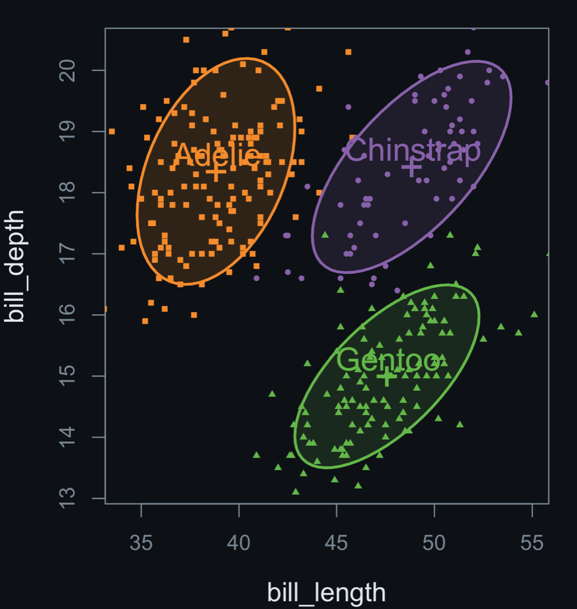

**covEllipses**(cbind(bill_length, bill_depth) ~ species, data = peng, pooled = FALSE, fill = TRUE, fill.alpha = 0.1)

### Start with one data ellipse per species

Each centre marks a species’ means. The size and tilt of each ellipse show its variances and correlation.

Pooling the three gives the E ellipse that the HE plot compares with the effect of species.

48

Figure slide: the plot redrawn on the slide background, with the R call that drew it underneath.

### The MANOVA juicer

Four measurements go in and two dimensions come out.

The first canonical dimension (86.5%) separates Gentoo from the other two; the second (13.5%) separates Adelie from Chinstrap.

The arrows show how each measurement contributes.

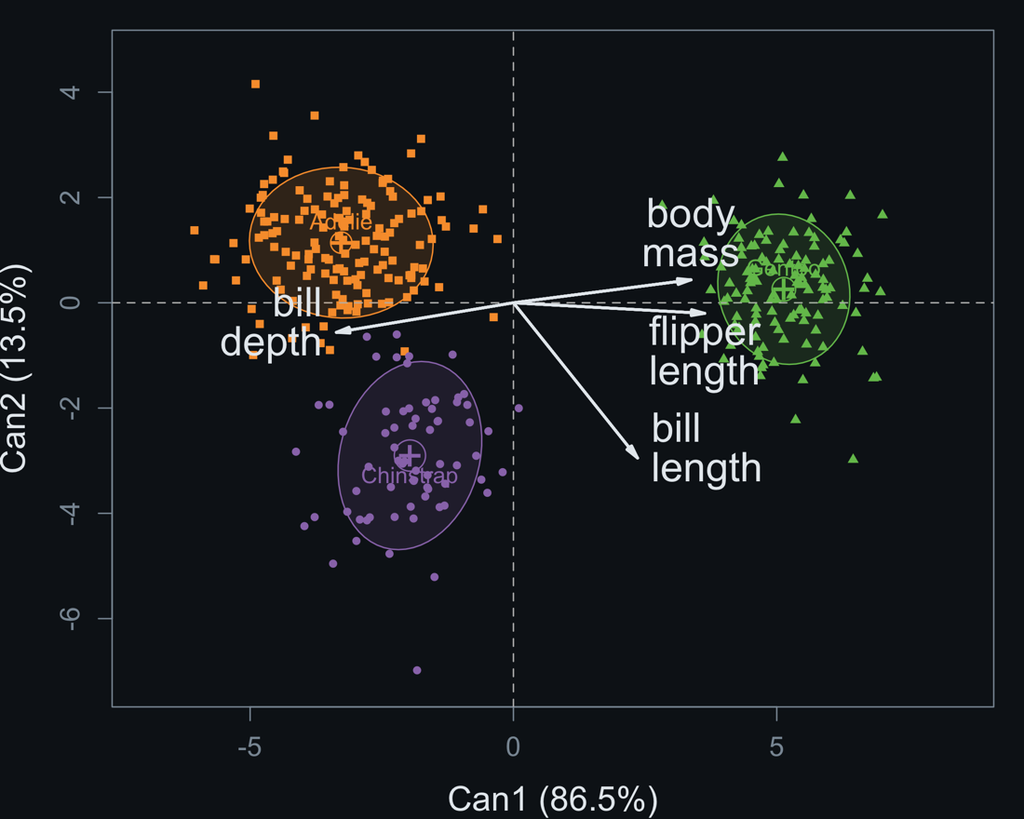

peng.can <- **candisc**(peng.mlm, data = peng) **plot**(peng.can, ellipse = TRUE)

60

Figure slide with the layout reversed: text on the left, plot and code on the right.

**Why it suits the talk.** It keeps what worked in the first Contour style: a dark room, the ellipse as the recurring shape, and code that answers “how did you make that?”. Every color and label now has a job.

**What to watch.** Every figure in the deck would need redrawing with dark settings: `par(bg = , fg = , col.axis = , col.lab = )` for base graphics, or a dark theme for ggplot2. Figures that can’t be redrawn, such as Galton’s diagram or the GIFs, would have to sit on a light panel. Some rooms show dark slides badly, so check the projector at Utrecht.

**In PowerPoint.** The contours are grouped ovals with their labels, saved as a picture and reused on each section divider with a different number. Code captions are text boxes in Fira Mono. Fira Sans and Fira Mono are free Google fonts.

## First round: possibly AI-looking

These are the four styles from the first round, unchanged apart from a corrected penguin count. Under each is a list of the habits it shares with AI-generated designs.

## Atlas Plate

A nod to the 19th-century statistical atlases that Michael writes about as a historian of data graphics. Figures are presented as numbered plates with captions, sections open like an atlas contents page, and slide numbers are folios. Galton's 1886 ellipse is the starting point.

Libre Caslon Text · IM Fell English SC (labels only)

paper

ink

madder

prussian

rule

A Romance in Many Dimensions

### Visualizing Multivariate Data and Models in R

Michael Friendly

Methodology & Statistics Group · Utrecht · 5 November MMXXVI

Title. One drawn ellipse with its axes is the only ornament.

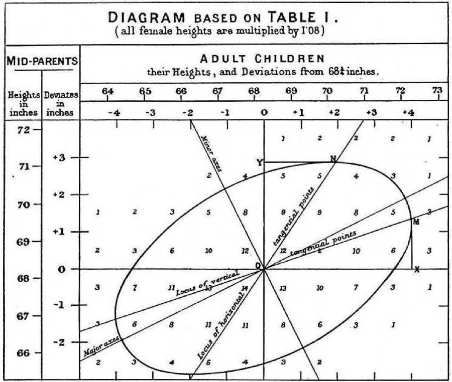

Part the First

### Ellipses Everywhere

seeing multivariate data

1. Galton's discovery11
2. The data ellipse12
3. What if I'm not Normal?17
4. Simpson's paradox18
5. Tours of the data22

— x —

Section divider styled as an atlas contents page.

Plate XII

### The data ellipse, by species

Fig. 12. — Bill depth against bill length for the Palmer penguins, with 68% data ellipses.

**I.**

The centre marks the *means*.

**II.**

Size and tilt give the *variances* and *correlation*.

**III.**

One ellipse per species shows what 333 points hide.

— xii —

Figure slide: numbered plate, caption, Roman-numeral remarks.

> I call our world Flatland, not because we call it so, but to make its nature clearer to you, my happy readers, who are privileged to live in Space. A. Square · Flatland · 1884

— v —

Quotation over faint concentric contours.

**Possible AI tells**

- Cream paper, a high-contrast serif and a rust-red accent: the “warm editorial” look that AI tools now default to
- Small letter-spaced capitals above the titles (“A Romance in Many Dimensions”, “Part the First”)
- Centered title and quotation slides
- Double-rule frame and hairline rules: newspaper styling on content that isn’t a newspaper
- Italic subtitles used as decoration

## Flatland Shapes

The plotting symbols in the book's penguin figures (Adelie ■, Chinstrap ●, Gentoo ▲) become the graphic system. Each section gets a Flatland rank, from triangle up to circle as the talk gains dimensions, and a row of these shapes in the footer shows how far along the talk is. Flat colour only: no gradients or shadows.

Archivo, expanded width for display, normal width for text · IBM Plex Mono for code

ground

ink

adelie

chinstrap

gentoo

### Visualizing Multivariate Data and Models in R

A Romance in Many Dimensions

MICHAEL FRIENDLYUtrecht · 5 November 2026

Title: ink block; the three species symbols overlap, with the overlaps cut out like paper.

1

### Ellipses everywhere

Seeing multivariate data

- GALTON
- DATA ELLIPSE
- NON-NORMAL
- SIMPSON
- TOURS

Ellipses

10

Section divider: a huge numeral, and the section's rank (a triangle) in its colour.

### The MANOVA juicer

**4 → 2**measures in, discriminant dimensions out

**86.5%**of the separation lies on Can1

HE plots

60

Figure slide: the plot on a white panel, key numbers in large type.

### Easy to fit. Hard to see.

`lm(cbind(bill_length, bill_depth, flipper_length, body_mass) ~ species)`

Why many dimensions

9

Statement slide: large type, and the model call in a code block.

**Possible AI tells**

- Overlapping geometric shapes used as decoration
- Big stand-alone numbers (“4 → 2”, “86.5%”) set out like a dashboard
- One phrase picked out in a different color (“Hard to see.”)
- All-caps tags in boxes, and an all-caps label in the footer

## Running Head

The slides take after the printed book: a running head, a coloured spine, and section colours taken from the book's four part colours. Titles state the finding in a full sentence (the assertion–evidence style). In the footer a row of small ellipses marks the section, with the current one filled.

Spectral (titles) · IBM Plex Sans (text) · IBM Plex Mono (code)

part I

part II

part III

part IV

ink

Methodology & Statistics · Utrecht University

### Visualizing Multivariate Data and Models in R

A Romance in Many Dimensions

Michael FriendlyYork University · 5 November 2026

Title: a four-part spine and overlapping ellipses in the part colours.

Section

2

### Multivariate juicers and Waldo space

1. PCA as a rotation
2. PCA by springs
3. Biplots: the data juicer
4. PCA vs. t-SNE

Section divider in the section's part colour, like a chapter opener.

**§4** The HE plot frameworkFriendly · Utrecht 2026

### The species differ on every pair of measures, not just one

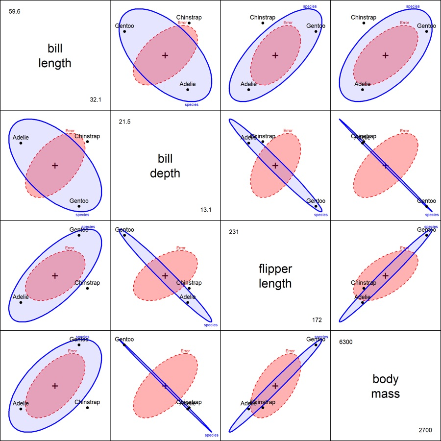

Each panel is an HE plot: the **H** ellipse for species against the **E** ellipse for error.

Where H pokes outside E, that pair of variables separates the species.

**Key point**All six panels show it: the effect is spread across the four measures.

52

Figure slide: the title states the result, the figure is the evidence, with a key-point box as in the book.

**§1** Ellipses everywhereFriendly · Utrecht 2026

### The same ellipse, 140 years apart

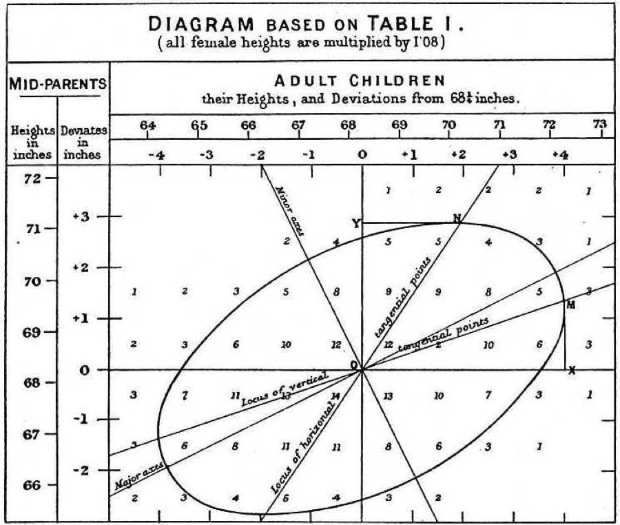

**Galton, 1886.** Heights of parents and children: the first data ellipse.

**Penguins, 2026.** One ellipse per species; `heplots::covEllipses()`

11

Comparison: two figures, with a caption under each, as in the book.

**Possible AI tells**

- Running head and “Section” label in small letter-spaced capitals
- “Friendly · Utrecht 2026”: facts strung together with dots
- A key-point box with a colored stripe down its left side, plus a colored stripe down the slide
- Small-caps eyebrow above the title (“Methodology & Statistics · Utrecht University”)

## Contour

A dark theme for a dim lecture room. The 50/68/95% contours of a data ellipse act as a map-like motif on dividers. Text accents use the *light* penguin shades, which are readable on dark backgrounds. Every figure has its R call as a caption, because the talk is about tools people can use.

Newsreader (display) · Spline Sans (text) · Spline Sans Mono (code captions)

night

ice

adelie·l

chin·l

gentoo·l

UTRECHT · 05 NOV 2026

### Visualizing Multivariate Data and Models in R: *a romance in many dimensions*

Michael FriendlyYork University, Toronto

Title: the slide-10 penguin photo fading into the dark background.

SECTION 03 / 05

### Elliptical insights

outliers · measurement error · collinearity · ridge

31

Section divider: contours, with the section's own contour drawn in its shade.

covEllipses(cbind(bill_length, bill_depth) ~ species,  
data = peng, fill = TRUE, level = 0.68)

### Start with the data ellipses

- Centre: the species means
- Shape: variances and correlation
- Next: pool them into **E**, compare with **H**

48

Figure slide: the figure on a light plate, with the R call that drew it underneath.

THE MANOVA JUICER, IN THREE NUMBERS

**4**measurements go in

**2**discriminant dimensions come out

**86.5%**of the separation on the first one

60

Statement slide: three large numbers in the three penguin shades, with the plot as a small inset.

**Possible AI tells**

- A near-black background with pale bright accents: the “dark signal” look
- Monospace labels used as decoration (“UTRECHT · 05 NOV 2026”, “SECTION 03 / 05”)
- Italic serif display headings, and one phrase of the title in italic
- The photo fades into the background through a gradient
- Three big numbers stacked as a stat block